# Plotting Tukey Test on ggplot

Edson Nilton de Moura Silva Júnior

19/03/2022

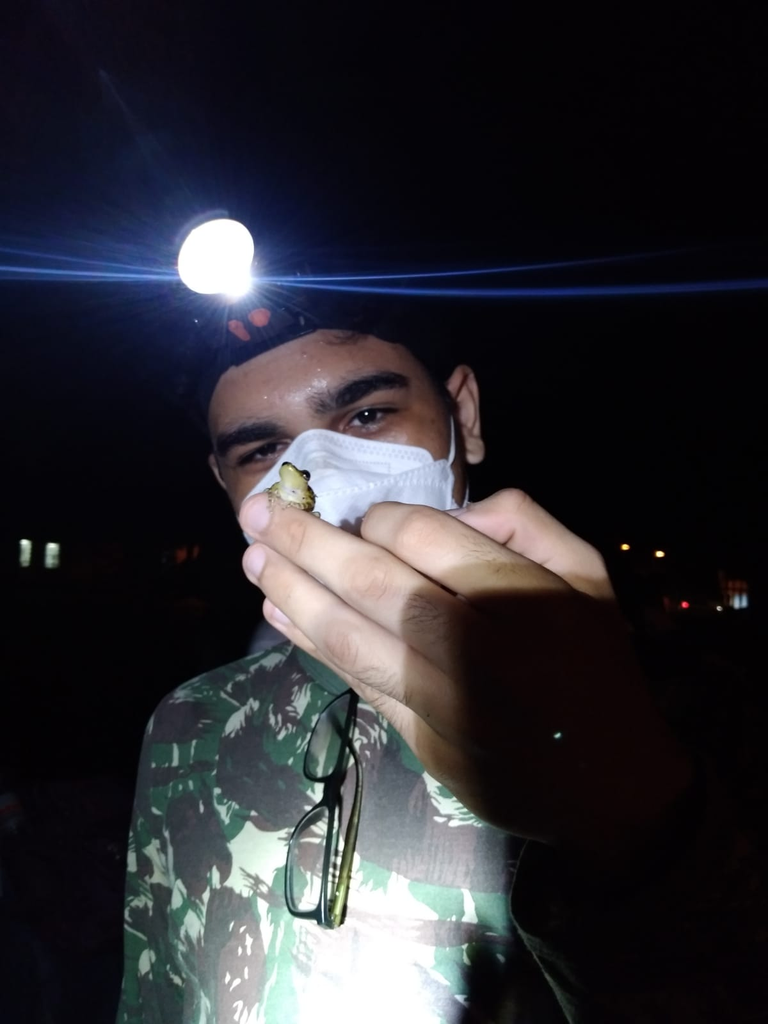

# **Introduction**

##### Tukey Pos-Hoc Test is an statistical test to avaliate which elements of a ANOVA (**An**alysis **o**f **Va**riation) analysis had variate between themself. As another analysis, Tukey Pos-Hoc Test can be plotted on graphics. On R Programing language, Tukey Pos-Hoc Test can be easily plotted with the **plot()** function.

## Plotting with **plot()**

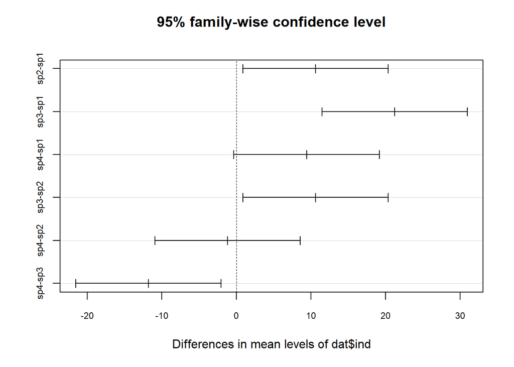

```r
sp1<-c(22,34,26,24,30)
sp2<-c(35,43,44,29,38)
sp3<-c(45,54,39,55,49)
sp4<-c(33,35,36,37,42)
dados<-data.frame(sp1,sp2,sp3,sp4)
dat<-stack(dados)
anova = aov(dat$values~dat$ind)
tk_teste <- TukeyHSD(anova)
plot(tk_teste, col="black", cex.axis=0.75)
```

##### As it can be understood, the bars that do not cruse the vertical line means a variation between two elements. In our situation, sp1-sp2 element means a variation between sp1 and sp2 groups. Although, it is a limitated plot graphic, in some situations. To resolute that, i created a function to make a ggplot plot Tukey Pos-Hoc Test.

# **Getting data**

## Loading the data

##### To make our analysis, we loading a databse of four landsites, which one containing data about the herpetofauna species diversity on number of species per landsites, assigning to a database called **testeanv**.

```r
setwd("G:/Meu Drive/R")
library(readxl)
testeanv<-read_xlsx("testeanova.exemplo.xlsx")
testeanv
```

```
## # A tibble: 20 × 2
##    Valores Locais
##      <dbl> <chr>
##  1      22 L1
##  2      34 L1
##  3      26 L1
##  4      24 L1
##  5      30 L1
##  6      35 L2
##  7      43 L2
##  8      44 L2
##  9      29 L2
## 10      38 L2
## 11      45 L3
## 12      54 L3
## 13      39 L3
## 14      55 L3
## 15      49 L3
## 16      33 L4
## 17      35 L4
## 18      36 L4
## 19      37 L4
## 20      42 L4
```

## R required database formate

##### To make the ANOVA analysis on R, it is necessary to formate the database in one way: a single colune with all the data of herpetofauna species diversity and an another single colune with the all landsites, corresponding with the previous rows data, as we can see above on the loaded database. To optimaze our analysis, it is necessary to certify if our data are on the R required database formate to do an ANOVA analysis.

# **Doing the analysis**

## ANOVA test

##### Our first step here is to make an ANOVA analysis with the **testeanv** database, therefore creating a aov objet.

```r
ANOVA<-aov(testeanv$Valores~testeanv$Locais)
summary(ANOVA)
```

```
##                 Df Sum Sq Mean Sq F value   Pr(>F)
## testeanv$Locais  3   1129   376.3   12.98 0.000149 ***
## Residuals       16    464    29.0
## ---
## Signif. codes:  0 '***' 0.001 '**' 0.01 '*' 0.05 '.' 0.1 ' ' 1
```

##### It was did an ANOVA analysis, with the command **aov()**, assigning it to a objet called **ANOVA**. Next step, we used the **summary()** command on **ANOVA** objet. That result had show us: p=0.000149. It means the groups variate themself, so it is available to proceed to the Tukey Pos-Hoc Test.

## Tukey test

##### With a **ANOVA** object, it can do a the Tukey Pos-Hoc Test, using **TukeyHSD()** command, assigning to an objetc called **TUKEY**.

```r
TUKEY<-TukeyHSD(ANOVA)
TUKEY
```

```
##   Tukey multiple comparisons of means
##     95% family-wise confidence level
##
## Fit: aov(formula = testeanv$Valores ~ testeanv$Locais)
##
## $`testeanv$Locais`
##        diff         lwr       upr     p adj
## L2-L1  10.6   0.8557176 20.344282 0.0306731
## L3-L1  21.2  11.4557176 30.944282 0.0000653
## L4-L1   9.4  -0.3442824 19.144282 0.0606123
## L3-L2  10.6   0.8557176 20.344282 0.0306731
## L4-L2  -1.2 -10.9442824  8.544282 0.9844430
## L4-L3 -11.8 -21.5442824 -2.055718 0.0151889
```

# **Created function**

## Creating the function

```r
GGTukey<-function(Tukey){
  A<-require("tidyverse")
  if(A==TRUE){
    library(tidyverse)
  } else {
    install.packages("tidyverse")
    library(tidyverse)
  }
  B<-as.data.frame(Tukey[1])
  colnames(B)[2:3]<-c("min",
                      "max")
  C<-data.frame(id=row.names(B),
                min=B$min,
                max=B$max)
  D<-C%>%
    ggplot(aes(id))+
    geom_errorbar(aes(ymin=min,
                     ymax=max),
                 width = 0.2)+
    geom_hline(yintercept=0,
               color="red")+
    labs(x=NULL)+
    coord_flip()+
    theme(text=element_text(family="TimesNewRoman"),
            title=element_text(color="black",size=15),
            axis.text = element_text(color="black",size=10),
            axis.title = element_text(color="black",size=10),
            panel.grid=element_line(color="grey75"),
            axis.line=element_blank(),
            plot.background=element_rect(fill="white",color="white"),
            panel.background=element_rect(fill="white"),
            panel.border = element_rect(colour = "black", fill = NA,size=0.59),
            legend.key= element_rect(color="white",fill="white")
          )
  return(D)
}
```

## Understandding the function and their elements

### Finishing the condictional function command

##### To finish the function, was used a **return()** command, to the **D** object. That command do the function, after made, return all the coded command in this function. The function is made.

# **Ggplot tukey test plotting**

## Creating a ggplot tukey test plotting

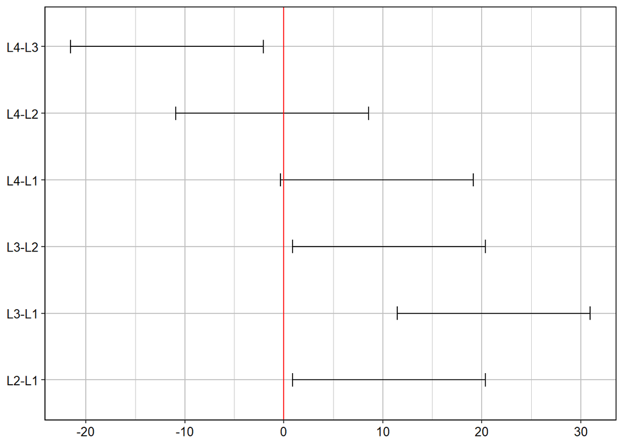

```r
GGTukey(TUKEY)
```

# **Differing by color**

##### Another way to make that ggplot graphic is differing the elements into **significant** and **not significant** by colors, insted using a vertical line crusing the 0 X axis value. That configuration allows identify the significant variantions using visual signals, being more easily interpretabel.

## Making the function

```r
GGTukey.2<-function(Tukey){
  A<-require("tidyverse")
  if(A==TRUE){
    library(tidyverse)
  } else {
    install.packages("tidyverse")
    library(tidyverse)
  }
  B<-as.data.frame(Tukey[1])
  colnames(B)[2:4]<-c("min",
                      "max",
                      "p")
  C<-data.frame(id=row.names(B),
                min=B$min,
                max=B$max,
                idt=ifelse(B$p<0.05,
                           "significant",
                           "not significant")
                )
  D<-C%>%
    ggplot(aes(id,color=idt))+
    geom_errorbar(aes(ymin=min,
                      ymax=max),
                  width = 0.5,
                  size=1.25)+
    labs(x=NULL,
         color=NULL)+
    scale_color_manual(values=c("red",
                                "green")
                       )+
    coord_flip()+
    theme(text=element_text(family="TimesNewRoman"),
            title=element_text(color="black",size=15),
            axis.text = element_text(color="black",size=10),
            axis.title = element_text(color="black",size=10),
            panel.grid=element_line(color="grey75"),
            axis.line=element_blank(),
            plot.background=element_rect(fill="white",color="white"),
            panel.background=element_rect(fill="white"),
            panel.border = element_rect(colour = "black", fill = NA,size=0.59),
            legend.key= element_rect(color="white",fill="white")
          )
  return(D)
}
```

##### In that script, the only four difference is:

##### name the fourth colunm on the **B** data frame object.

##### creat a new colunm in the **C** data frame, named **idt**.

##### in **aes()** command, was assigned color=idt.

##### to define the color by the significant or not significant elements, based on p-value, using **scale_color_manual()** command.

## Creating a ggplot tukey test plotting

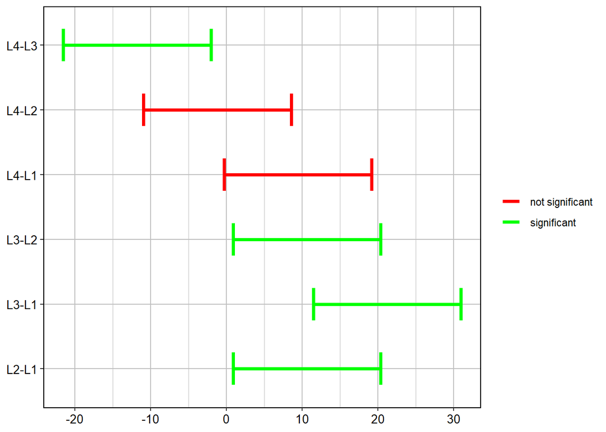

```r
GGTukey.2(TUKEY)
```

# **Using the both ways**

## Making the function

```r
GGTukey.3<-function(Tukey, Style){
  GT<-function(Tukey){
    A<-require("tidyverse")
    if(A==TRUE){
      library(tidyverse)
    } else {
      install.packages("tidyverse")
      library(tidyverse)
    }
    B<-as.data.frame(Tukey[1])
    colnames(B)[2:3]<-c("min",
                        "max")
    C<-data.frame(id=row.names(B),
                  min=B$min,
                  max=B$max)
    D<-C%>%
      ggplot(aes(id))+
      geom_errorbar(aes(ymin=min,
                        ymax=max),
                    width = 0.2)+
      geom_hline(yintercept=0,
                 color="red")+
      labs(x=NULL)+
      coord_flip()+
      theme(text=element_text(family="TimesNewRoman"),
            title=element_text(color="black",size=15),
            axis.text = element_text(color="black",size=10),
            axis.title = element_text(color="black",size=10),
            panel.grid=element_line(color="grey75"),
            axis.line=element_blank(),
            plot.background=element_rect(fill="white",color="white"),
            panel.background=element_rect(fill="white"),
            panel.border = element_rect(colour = "black", fill = NA,size=0.59),
            legend.key= element_rect(color="white",fill="white")
            )
    return(D)
  }
  GT2<-function(Tukey){
    A<-require("tidyverse")
    if(A==TRUE){
      library(tidyverse)
    } else {
      install.packages("tidyverse")
      library(tidyverse)
    }
    B<-as.data.frame(Tukey[1])
    colnames(B)[2:4]<-c("min",
                        "max",
                        "p")
    C<-data.frame(id=row.names(B),
                  min=B$min,
                  max=B$max,
                  idt=ifelse(B$p<0.05,
                             "significant",
                             "not significant")
    )
    D<-C%>%
      ggplot(aes(id,color=idt))+
      geom_errorbar(aes(ymin=min,
                        ymax=max),
                    width = 0.5,
                    size=1.25)+
      labs(x=NULL,
           color=NULL)+
      scale_color_manual(values=c("red",
                                  "green")
      )+
      coord_flip()+
      theme(text=element_text(family="TimesNewRoman"),
            title=element_text(color="black",size=15),
            axis.text = element_text(color="black",size=10),
            axis.title = element_text(color="black",size=10),
            panel.grid=element_line(color="grey75"),
            axis.line=element_blank(),
            plot.background=element_rect(fill="white",color="white"),
            panel.background=element_rect(fill="white"),
            panel.border = element_rect(colour = "black", fill = NA,size=0.59),
            legend.key= element_rect(color="white",fill="white")
            )
    return(D)
  }
  GR<-if(Style==1){
    return(GT(Tukey))
  } else if(Style==2){
    return(GT2(Tukey))
  }
  return(GR)
}
```

##### In this script combining the previously both functions. To chose which plot aesthectic, more than TukeyHSD object, was created a variable named **Style**. To make the algoritimical process, it was used the **if()** and **else if()** condictional command, in which **Style=1** creat the ggplot with a vertical red line, and **Style=2** Creat the ggplot using collors to differing the significan and not significant elements.

## Creating the plots

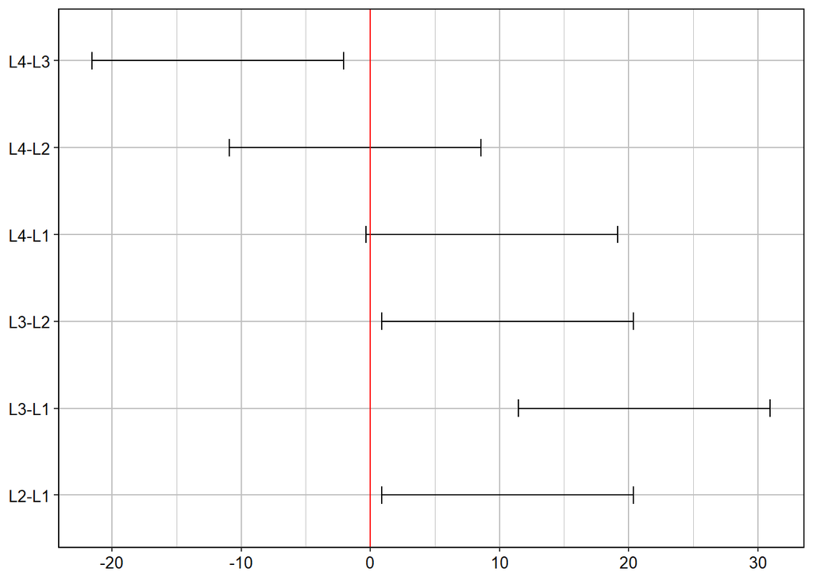

```r
GGTukey.3(TUKEY,Style=1)
```

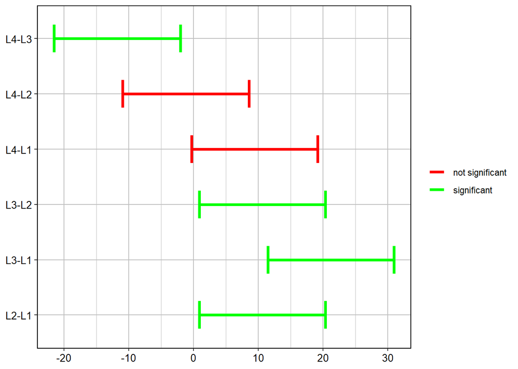

```r
GGTukey.3(TUKEY,Style=2)
```